# PROYECTO FINAL MODULO III

Israel Balbuena

2024-12-11

# SECCION A: RELACIÓN ENTRE OFERTA MONETARIA, EXPORTACIONES Y GASTO PÚBLICO DE MÉXICO

La teoría económica sostiene que la oferta monetaria de un país está en función de variables como la tasa de interés fijada por el banco central, el nivel de exportaciones y el gasto público. Este ejercicio tiene como objetivo construir un modelo de regresión lineal para determinar la relación marginal entre la oferta monetaria, el gasto del sector público y las exportaciones de México durante el período 1993 - 2024.

En este sentido, la base de datos cuenta con registros que van desde enero de 1993 hasta septiembre de 2024 con una frecuencia mensual de las variables oferta monetaria, exportaciones, gasto presupuestal, Indice Nacional de Precios al Consumidor y tipo de cambio. Los datos fueron recolectados a través de la API del Banco de México y de la página del INEGI y fueron deflactados tomando como año base el valor del INPC de septiembre de 2024.

|  | fecha | Oferta_monetaria | Exportaciones | Gasto_presupuestal | Tipo_cambio | INPC |
| --- | --- | --- | --- | --- | --- | --- |
| 1 | 1993-01-01 | 385892758794.574 | 113810666789.2909 | 196239990999.6826 | 3.109 | 12.97732 |
| 2 | 1993-02-01 | 372186105929.3323 | 123245657723.6674 | 387602992354.0196 | 3.0986 | 13.083345 |
| 3 | 1993-03-01 | 358599348830.9746 | 143161515465.4005 | 649383246929.9586 | 3.1082 | 13.159594 |
| 4 | 1993-04-01 | 360843959919.8518 | 131523647629.0154 | 840366083285.2303 | 3.0966 | 13.23548 |
| 5 | 1993-05-01 | 369074532431.0012 | 131715566002.4937 | 1045839329277.432 | 3.1231 | 13.311137 |
| 6 | 1993-06-01 | 366532443538.4759 | 151987225497.8246 | 1302072344889.139 | 3.1212 | 13.385797 |
| 7 | 1993-07-01 | 372331811151.4669 | 131215483149.6462 | 1567556442420.638 | 3.1237 | 13.450123 |
| 8 | 1993-08-01 | 353399972702.4891 | 132154552665.528 | 1781542349597.459 | 3.1123 | 13.522112 |
| 9 | 1993-09-01 | 350904596727.3715 | 138286825236.9911 | 1997423726942.246 | 3.113 | 13.622261 |
| 10 | 1993-10-01 | 369529411733.7416 | 152579087670.1301 | 2226932006957.464 | 3.1148 | 13.677973 |

[output cut: 371 more lines]

## ANALISIS GRÁFICO

Gráficamente, puede observarse que tanto las exportaciones como el nivel de gasto público en el período de análisis tuvieron una relación positiva con la oferta monetaria: a medida que aumentaron las exportaciones y el gasto público, también aumentó el número de billetes y monedas en circulación. Esta situación es corroborada estadísticamente por los coeficientes de correlación de Pearson de 0.93 y 0.52 entre la ofera monetaria y las exportaciones y entre la oferta monetaria y el gasto presupuestal.

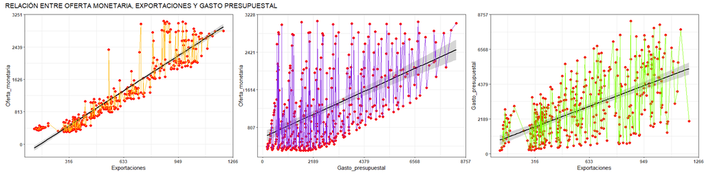

No obstante, las exportaciones y el gasto público también presentaron una relación positiva entre 1993 y 2024 que es capturada por un coeficiente de correlación de Pearson de 0.59. La importancia de esta relación no es menor a la hora de construir modelos de regresión lineal debido a que estos asumen la independencia de las variables regresoras para el calculo de los parámetros poblacionales.

Adicionalmente, el análisis gráfico muestra que las distribuciones de probabilidad de las variables utilizadas para la construcción del modelo de regresión lineal no siguen una distribución normal con media 0 y desviación estandar 1. De hecho, tanto la oferta monetaria como el gasto prespuestal presentan distribuciones con sesgos positivos: la moda y la mediana son menores a la media.

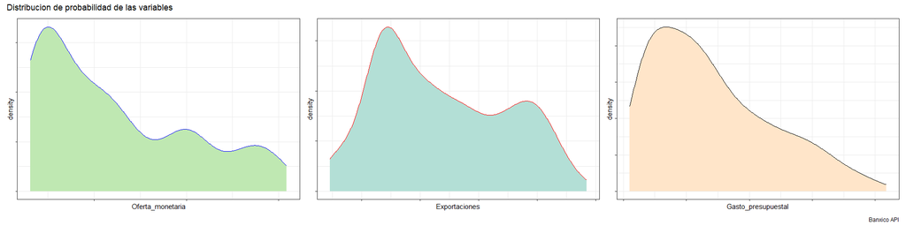

## MODELO INICIAL

Después de la construcción y análisis de diveros modelos de regresión lineal que consideraron transformaciones logarítmicas, boxcox y raices de diferentes grados de las variables, el mejor modelo considera la transformación logarítmica tanto de la variable dependiente como de las variables independientes y la utilización de la modelación de la varianza como pesos en la regresión

Inicialmente, fue construído un modelo de regresión lineal considerando el logaritmo de la oferta monetaria como una función lineal de los logaritmos de las exportaciones y del gasto público.El modelo inicial muestra que un aumento de 1 punto porcentual en las exportaciones genera un aumento de 1.2 puntos porcentuales en la oferta monetaria disponible en el país. Aunque el gasto presupuestal no tiene un efecto estadisticamente significativo sobre la oferta monetaria, el mododelo es capaz de explicar el 83.3 % de la variación en la oferta monetaria en el período con 95% de confianza.

Resultados de la Regresión Lineal

| term | estimate | std.error | statistic | p.value | significance |
| --- | --- | --- | --- | --- | --- |
| (Intercept) | -5.421422 | 0.7658781 | -7.0787003 | 0.0000000 | *** |
| log(Exportaciones) | 1.214134 | 0.0330641 | 36.7205925 | 0.0000000 | *** |
| log(Gasto_presupuestal) | 0.009168 | 0.0211328 | 0.4338285 | 0.6646605 |  |

### PRUEBA DE NORMALIDAD

De acuerdo tanto con el análisis gráfico como las pruebas Jarque-Bera,Shapiro-Wilk y Anderson-Darling, los residuos del modelo inicial no siguen una distribución normal alrededor de los valores predichos. Los p-values obtenidos aportan suficiente evidencia para rechazar el supuesto de normalidad de los residuos con 95% de confianza

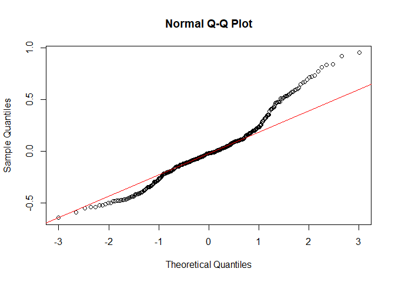

```
##
##  Jarque-Bera Normality Test
##
## data:  as.vector(modelo1$residuals)
## JB = 31.272, p-value = 0.0000001619
## alternative hypothesis: greater
```

```
##
##  Shapiro-Wilk normality test
##
## data:  modelo1$residuals
## W = 0.96491, p-value = 0.00000006416
```

```
##
##  Anderson-Darling normality test
##
## data:  modelo1$residuals
## A = 4.2693, p-value = 0.0000000001269
```

### PRUEBA DE MULTICOLINEALIDAD

Las variables independientes del modelo inicial no están correlacionadas de acuerdo con el estadístico de inflación de la varianza por lo que no hay evidencia suficiente para rechazar la hipotesis nula de no multicolinealidad entre variables independientes.

```
##      log(Exportaciones) log(Gasto_presupuestal)
##                1.394399                1.394399
```

### PRUEBA DE HOMOCEDASTICIDAD

La varianza de los residuos del modelo incial no es constante a medida que aumentan los valores de las variables independientes. De acuerdo con las pruebas Breusch-Pagan y chi-cuadrada hay evidencia suficiente para rechazar la varianza constante de los residuos.

```
##
##  studentized Breusch-Pagan test
##
## data:  modelo1
## BP = 120.82, df = 2, p-value < 0.00000000000000022
```

```
## Non-constant Variance Score Test
## Variance formula: ~ fitted.values
## Chisquare = 159.3098, Df = 1, p = < 0.000000000000000222
```

### PRUEBA DE AUTOCORRELACION

Los residuos del modelo inicial están correlacionados con sus valores pasados de acuerdo con la prueba Durbin-Watson. El p-value aporta evidencia suficiente para rechazar la no autocorrelación de los residuos.

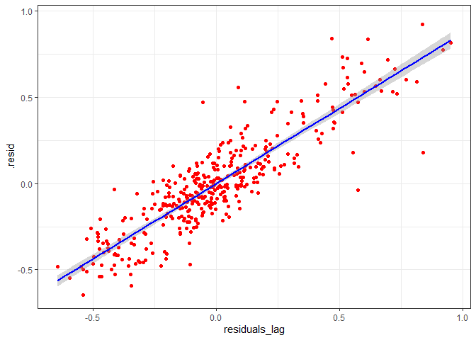

```
##
##  Durbin-Watson test
##
## data:  modelo1
## DW = 0.23121, p-value < 0.00000000000000022
## alternative hypothesis: true autocorrelation is greater than 0
```

### PRUEBA DE ESTABILIDAD DE LOS PARAMETROS

Los parametros calculados por el método de mínimos cuadrados ordinarios no son los mismos entre categorias de los datos o a lo largo del tiempo por lo que el modelo no es útil para hacer predicciones. Esta prueba es la más importante debido a que de ella depende la utilidad del modelo para realizar predicciones entre diferentes categorias de datos o niveles de variables.

```
##
##  M-fluctuation test
##
## data:  modelo1
## f(efp) = 4.1594, p-value = 0.000000000000005662
```

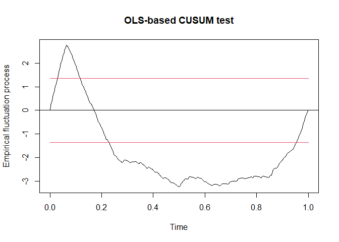

### PRUEBA DE ESPECIFICIDAD O LINEALIDAD

De acuerdo con la prueba de especificidad, el modelo inicial no está bien especificado debido a que faltan variables o la relación no es lineal.

```
##
##  RESET test
##
## data:  modelo1
## RESET = 228.41, df1 = 2, df2 = 376, p-value < 0.00000000000000022
```

## MODELO FINAL

El modelo propuesto inicialmente sólo cumple con el supuesto de no correlación entre las variables independientes por lo que no es un modelo útil para realizar predicciones. Después de probar diferentes transformaciones tanto de a variable dependiente como de las variables independientes, el mejor modelo encontrado contempla la modelación de la varianza y el calculo de los errores standar libres de autocorrelacion mediante NeweyWest.

Al modelar la varianza del modelo inicial e incluirla como los pesos de la regresión, los coeficientes y los valores de confianza cambian. Por un lado, el coeficiente del intercepto sigue siendo significativo a un nivel de confianza de 95%, aunque su valor pasó de -5.42 a -10.17. Por otro lado, el logatirmo de las exportaciones sigue siendo significativo a un nivel de confianza de 99%, aunque el valor de su coeficiente pasó de a 1.21 a 1.38. Por su parte, el logaritmo del gasto presupuestal siguió sin ser significativo en el modelo.

Resultados de la Regresión Lineal

std.error

statistic

p.value

significance

(Intercept)

-10.1737758

4.5918731

-2.215605

0.0273138

log(Exportaciones)

1.3852671

0.1680046

8.245413

0.0000000

***

log(Gasto_presupuestal)

0.0128463

0.0106078

1.211025

0.2266424

### PRUEBA DE NORMALIDAD

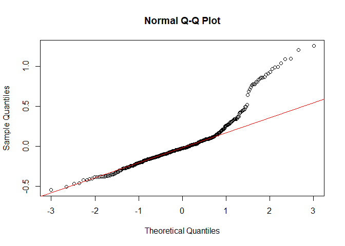

```
##
##  Jarque-Bera Normality Test
##
## data:  as.vector(modelo3$residuals)
## JB = 279.57, p-value < 0.00000000000000022
## alternative hypothesis: greater
```

```
##
##  Shapiro-Wilk normality test
##
## data:  modelo3$residuals
## W = 0.873, p-value < 0.00000000000000022
```

```
##
##  Anderson-Darling normality test
##
## data:  modelo3$residuals
## A = 14.006, p-value < 0.00000000000000022
```

### PRUEBA DE MULTICOLINEALIDAD

El modelo final no presenta problemas de colinealidad entre las variables independientes, así como el modelo incial.

```
##      log(Exportaciones) log(Gasto_presupuestal)
##                1.024642                1.024642
```

### PRUEBA DE HOMOCEDASTICIDAD

El modelo final present problemas de heterocedasticidad de acuerdo con la prueba Breusch-Pagan

```
##
##  studentized Breusch-Pagan test
##
## data:  modelo3
## BP = 13044123, df = 2, p-value < 0.00000000000000022
```

```
## Non-constant Variance Score Test
## Variance formula: ~ fitted.values
## Chisquare = 221.2626, Df = 1, p = < 0.000000000000000222
```

### PRUEBA DE AUTOCORRELACION

El modelo final presenta problemas de autocorrelación entre los residuos en diferentes tiempos.

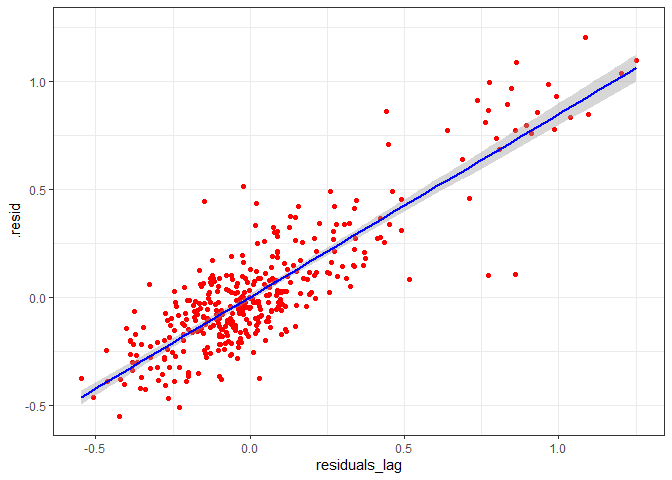

### PRUEBA DE ESTABILIDAD DE LOS PARAMETROS

Los coeficientes(parametros) del modelo final ahora son estables a lo largo del tiempo y entre categorias de los datos, a diferencia del modelo inicial que no tiene estabilidad en sus parametros. Esto es de suma importancia debido a que el modelo final sí puede usarse para generar predicciones de la variable dependiente.

```
##
##  M-fluctuation test
##
## data:  modelo3
## f(efp) = 1.2608, p-value = 0.2295
```

[figure not shown]

### PRUEBA DE ESPECIFICIDAD O LINEALIDAD

El modelo final no está bien especificado: puede ser que existan variables importantes que deberían ser incluidas o que sea necesario probar otras transformaciones sobre las variables del modelo.

```
##
##  RESET test
##
## data:  modelo3
## RESET = 228.41, df1 = 2, df2 = 376, p-value < 0.00000000000000022
```

### NEWYWEST

Los problemas de normalidad, heterocedasticidad y autocorrelación en un modelo de regresión afectan el calculo de los errores estandar de los coeficientes, haciendo que los p-values de las pruebas de significancia estadistica no sean confiables. El método newyweste sirve para calcular los erres estandar de los coeficientes en presencia de no normalidad, heterocedasticidad y autocorrelación en un modelo de regresión con el objetivo de obtener p-values confiables sobre la significacia estadistica de los parámetros.

De esta manera, el método newywest sobre el modelo final establece que tanto el intercepto como el logaritmo de las exportaciones son variables estadísticamente significativas que explican la variación de la variable dependiente con una confianza mayor a 95%; mientras que el logaritmo del gasto presupuestal no es estadísticamente significavo.

```
##
## t test of coefficients:
##
##                           Estimate Std. Error t value              Pr(>|t|)
## (Intercept)             -10.173776   3.276754 -3.1048              0.002047 **
## log(Exportaciones)        1.385267   0.128674 10.7657 < 0.00000000000000022 ***
## log(Gasto_presupuestal)   0.012846   0.040122  0.3202              0.749011
## ---
## Signif. codes:  0 '***' 0.001 '**' 0.01 '*' 0.05 '.' 0.1 ' ' 1
```

# SECCION B: MODELO DE REGRESIÓN MULTIPLE